# Assignment 3: Incarceration

Taeyun Kim

11/21/2021

## *Introduction*

In this project, the dataset contains number of various populations by their *races* in jail and prison from 1970 to 2018. The data that I gave more focus on are the **black population** who are either in *jail* or *prison*. Also, by making charts, it became able to see the trend of black population in prison; the relationship between black population vs black prisoner in CA; the overall population of black population in jail in 2018. By doing so, it helped visualizing how the black populations were treated regarding the American jail/prison.

## *Summary*

The dataset contains data regarding *jail* and *prison*. The year that jail had the most population is `1993` while the year that prison had the most population is `2007`. While the *prison* had maximum of `24818` black population and `9945` white population, the *jail* had maximum of `13143.92` black population and `7036.59` white population. I also used the dataset to determine the state with the highest population with specific race. `CA` has both the highest black and white population in jail. For prison, `NY` has the most black population while `CA` has the most white population.

## *Trends Over Time Chart*

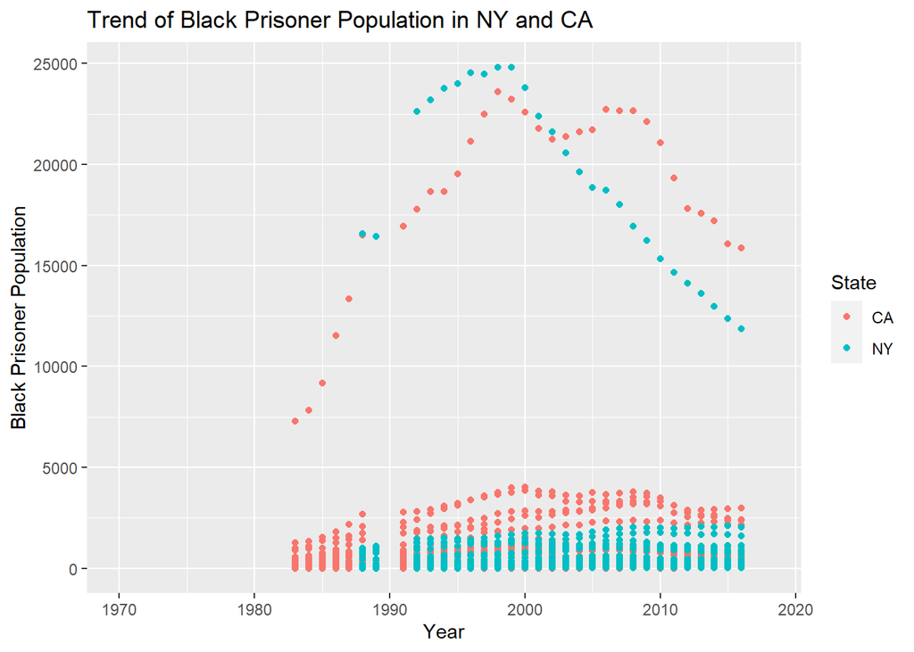

## *Variable Comparison Chart*

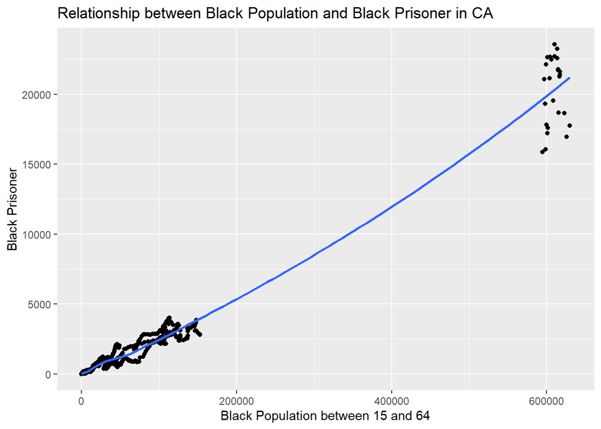

From the variables regarding the state with the highest jail or prison population, **“CA”** was constantly showing up as the answer. So, I plotted this chart that shows the relationship between the black population(15 to 64 years old) and the number of black prisoners in CA.  
The graph seems to be a straight line with a positive slope. This could indicate that as the black population increases, the number of black prisoner also increases in CA. However, I am not sure if we can give a credit to this graph because it seems little bit obvious that if there are larger population, there could be a higher number of population who commits crimes and go to the prison.  
But regardless, the graph shows that there is a *positive relationship* between the black population and black prisoners

## *Map*

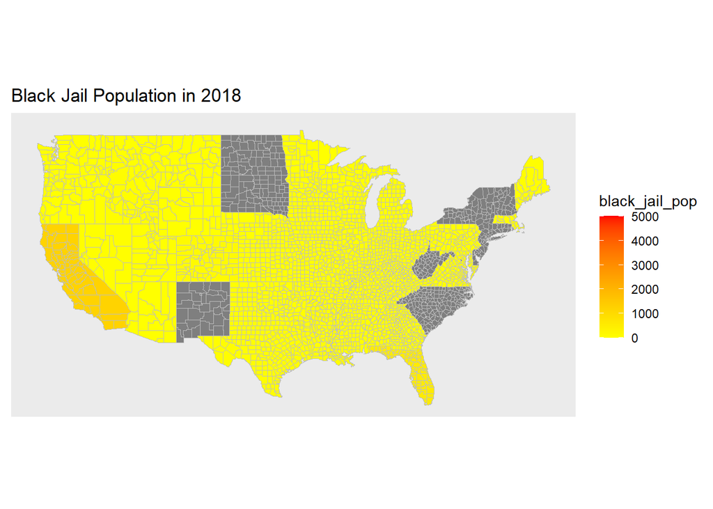